# Data processing

## Read and clean data

```r
# reading data frame
data_frame <- read.csv("data/data_preprocessed/data.csv")

# removing rows we are not interested in
df_clean <- subset(data_frame, original_sentence != "")
# removing practice trials
df_clean <- subset(df_clean, !is.na(correct_change_answer))
```

## Demographic overview

```r
demographics <- df_clean %>%
  group_by(participant) %>%
  summarise(language = first(language),
            age = first(age),
            education = first(education))

demographics
```

```
## # A tibble: 41 × 4
##    participant language      age education
##    <chr>       <chr>       <int> <chr>
##  1 0j67qkfv    Kalaallisut    26 Ilinniarnertuunngorniarfik naammassinikuuara
##  2 4fpy89hk    Kalaallisut    37 Meeqqat atuarfiat
##  3 4wx25059    Kalaallisut    21 Meeqqat atuarfiat
##  4 5kqwq452    Kalaallisut    17 Meeqqat atuarfiat
##  5 5tqs1axn    Kalaallisut    54 Meeqqat atuarfiat
##  6 5zdl50pp    Kalaallisut    60 Naatsumik ilinniagaqarpunga
##  7 61fs8fwl    Kalaallisut    17 Meeqqat atuarfiat
##  8 69m7zrjp    Kalaallisut    17 Meeqqat atuarfiat
##  9 9v037h4b    Kalaallisut    59 Meeqqat atuarfiat
## 10 a4kn5z8j    Kalaallisut    69 Naatsumik ilinniagaqarpunga
## # ℹ 31 more rows
```

```r
# excluding one participant who answered Danish as first language
# -------------------------------------------------------------
participant_to_exclude1 <- c("l4kkhlaf")
df_clean <- subset(df_clean, !participant %in% participant_to_exclude1)
data_frame <- subset(data_frame, !participant %in% participant_to_exclude1)
```

## Excluding participants whose accuracy is too close to chance level

Here, we check the participants’ accuracy across all trials. If the accuracy rate is at chance level, the participants are excluded from further data analysis, as it is too probable that they have just answered randomly.

```r
# making a "correct/incorrect"-column
df_clean$correct_incorrect <- ifelse(
  df_clean$Ychange_Nchange_response == "no" & df_clean$correct_change_answer == "no_change" |
    df_clean$Ychange_Nchange_response == "yes" & df_clean$correct_change_answer == "affix_deletion" & df_clean$response == df_clean$correct_response |
    df_clean$Ychange_Nchange_response == "yes" & df_clean$correct_change_answer == "other_change" & df_clean$response == df_clean$correct_response |
    df_clean$Ychange_Nchange_response == "yes" & df_clean$correct_change_answer == "subject_deletion"& df_clean$response == df_clean$correct_response,
  1, 0)

# how many correct does each participant have?
df_correct_count <- df_clean %>%
  group_by(participant) %>%
  summarize(correct_count = sum(correct_incorrect))

# looking at the binomial distribution, we can see that the cutoff point must be 43 incorrect answers (p = 0.05).
# if participants have more than 43 incorrect answers (less than 53 correct), it is too probable that they have answered randomly
# note that this assumes equal 50% guessing probability per trial
dbinom(x=43,size=96,prob=0.5)
```

```
## [1] 0.0484641
```

```r
dbinom(x=44,size=96,prob=0.5)
```

```
## [1] 0.05837721
```

```r
# excluding participants that have less than 53 correct
participants_to_exclude2 <- subset(df_correct_count$participant, df_correct_count$correct_count < 53)
df_clean <- subset(df_clean, !participant %in% participants_to_exclude2)
data_frame <- subset(data_frame, !participant %in% participants_to_exclude2)
```

## Excluding participants who spent too long on the experiment

```r
# checking how long they spent on the change detection part of the experiment
df_time_change_detection <- df_clean %>%
  group_by(participant) %>%
  summarise(total_time = max(time_elapsed, na.rm = TRUE)/60000)
df_time_change_detection
```

```
## # A tibble: 37 × 2
##    participant total_time
##    <chr>            <dbl>
##  1 0j67qkfv          27.7
##  2 4wx25059          22.9
##  3 5kqwq452          53.5
##  4 5tqs1axn          32.7
##  5 5zdl50pp          33.4
##  6 61fs8fwl          26.1
##  7 69m7zrjp          25.6
##  8 9v037h4b          30.5
##  9 a4kn5z8j          39.2
## 10 b7ctmky7          24.2
## # ℹ 27 more rows
```

```r
# excluding outliers whose total time spent on the change detection part was more than 3 SDs from the mean
mean_time <- mean(df_time_change_detection$total_time)
sd_time <- sd(df_time_change_detection$total_time)
cutoff <- mean_time + 3*sd_time
cutoff
```

```
## [1] 59.1766
```

```r
participants_above_cutoff <- ("knkl4dbx")
df_clean <- subset(df_clean, !participant %in% participants_above_cutoff)
data_frame <- subset(data_frame, !participant %in% participants_above_cutoff)
```

## Overview of mean reaction times

Here is an overview of the mean reaction times for the three stages of the trials (initial sentence reading, change detection, localization).

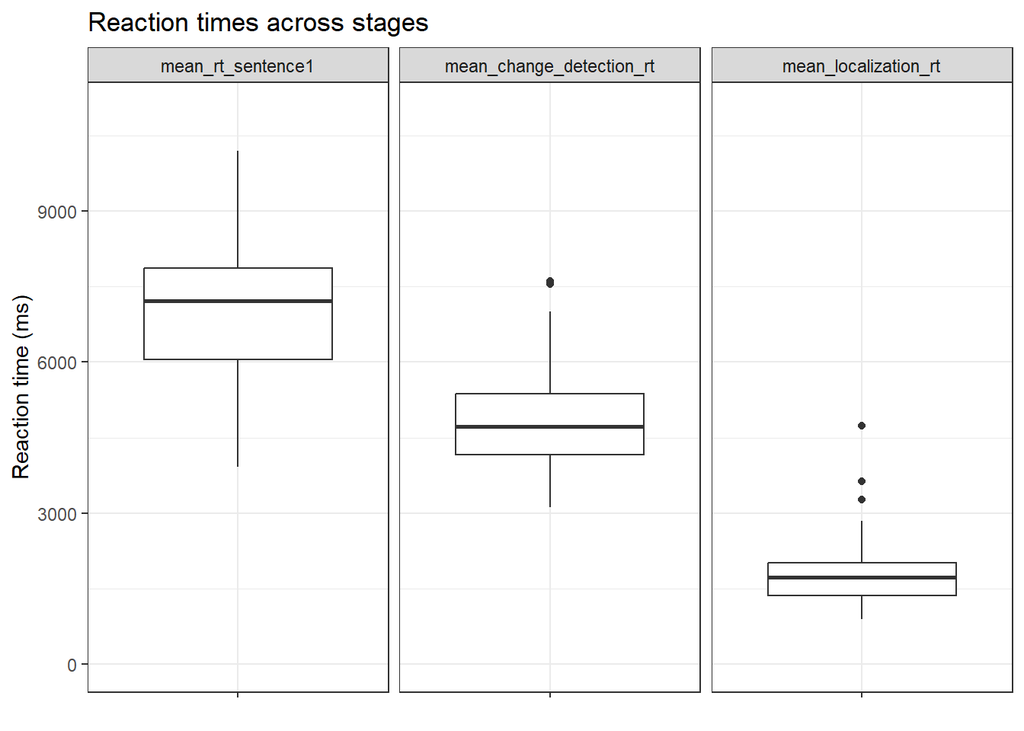

```r
reading_time_first_sentence <- data_frame %>%
  group_by(participant, sentence_id_specific) %>%
  summarise(reading_time_sentence1 = first(rt))
mean_reading_time_first_sentence <- reading_time_first_sentence %>%
  filter(!(sentence_id_specific %in% c("p1", "p2", "p3", "p4", NA))) %>%
  group_by(participant) %>%
  summarise(mean_rt_sentence1 = mean(reading_time_sentence1))

change_detection_time <- data_frame %>%
  group_by(participant, sentence_id_specific) %>%
  summarise(change_detection_time = rt[[2]])
mean_change_detection_time <- change_detection_time %>%
  filter(!(sentence_id_specific %in% c("p1", "p2", "p3", "p4", NA))) %>%
  group_by(participant) %>%
  summarise(mean_change_detection_rt = mean(change_detection_time))

localization_time <- data_frame %>%
  group_by(participant, sentence_id_specific) %>%
  summarise(localization_time = rt[[3]])
mean_localization_time <- localization_time %>%
  filter(!(sentence_id_specific %in% c("p1", "p2", "p3", "p4", NA))) %>%
  group_by(participant) %>%
  summarise(mean_localization_rt = mean(localization_time))

rt_different_stages <- merge(merge(mean_reading_time_first_sentence, mean_change_detection_time), mean_localization_time)

rt_long <- rt_different_stages %>%
  pivot_longer(
    cols = c(
      mean_rt_sentence1,
      mean_change_detection_rt,
      mean_localization_rt
    ),
    names_to = "stage",
    values_to = "rt"
  )

rt_plot <- ggplot(rt_long, aes(x = "", y = rt)) +
  geom_boxplot() +
  facet_wrap(~ factor(stage, c("mean_rt_sentence1", "mean_change_detection_rt", "mean_localization_rt"))) +
  ylim(c(0,11000)) +
  labs(
    x = NULL,
    y = "Reaction time (ms)",
    title = "Reaction times across stages"
  ) +
  theme_bw()

rt_plot
```

```r
ggsave("figures/rt_different_stages.png", plot = rt_plot, width = 9, height = 4)
```

## Discarding individual outlier trials with very long reaction times

We discard trials where the sum of the reaction times on the three stages (initial sentence reading, change detection, change localization) is more than three SDs above the participant’s own mean. We do this because very long RTs can indicate that the participant zoned out or did not pay attention to the task.

```r
# get reaction times for all trials
rt_different_stages_full <- merge(merge(reading_time_first_sentence, change_detection_time), localization_time) %>%
  filter(!(sentence_id_specific %in% c("p1", "p2", "p3", "p4", NA))) %>%
  mutate(sum_rt = reading_time_sentence1 + change_detection_time + localization_time)

# calculate participant means and SDs - and merge
rt_mean_and_SD <- rt_different_stages_full %>%
  group_by(participant) %>%
  summarise(mean_rt = mean(sum_rt),
            sd_rt = sd(sum_rt))
rt_different_stages_full_merged <- merge(rt_different_stages_full, rt_mean_and_SD, by = "participant")

# get outlier trials
rt_outliers <- rt_different_stages_full_merged %>%
  filter(sum_rt > mean_rt + 3 * sd_rt)

# exclude outliers
df_clean <- df_clean %>%
  anti_join(rt_outliers, by = c("participant", "sentence_id_specific"))
```

# Comparing accuracy in the lexical and grammatical conditions

First, let’s check the localization accuracy: Among the affix deletions that were correctly detected, how many were correctly localized?

```r
df_clean_affix <- subset(df_clean, correct_change_answer == "affix_deletion")

# LOCALIZATION
df_clean_correct <- df_clean_affix %>%
  filter(correct_incorrect == 1)

df_clean_correct$localization_correct <- ifelse(
  df_clean_correct$response == df_clean_correct$correct_response,
  1, 0
)

mean(df_clean_correct$localization_correct)
```

```
## [1] 1
```

All of them were correctly localized. Therefore, we from now on can focus only on change detection accuracy and not worry about the localization step.

## Two plots

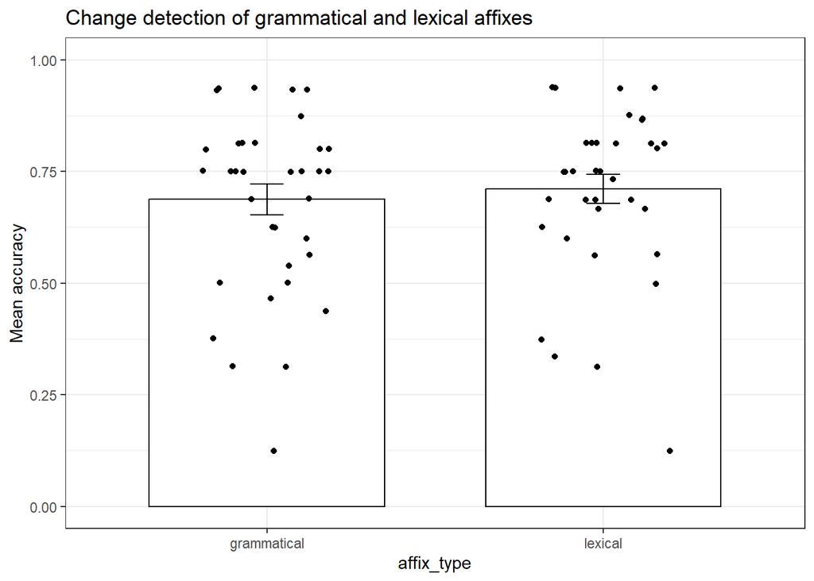

```r
# bar plot
# --------

# group the data by participant and calculate the mean number of correct responses per participant
# in the two conditions
df_participant_mean <- df_clean_affix %>%
  group_by(participant, affix_type) %>%
  summarise(mean_accuracy = mean(correct_incorrect),
            .groups = "drop")


# make a bar plot with errorbars and jitter points
accuracy_barplot <- ggbarplot(df_participant_mean,
                              x = "affix_type",
                              y = "mean_accuracy",
                              add = c("mean_se", "jitter"),
                              xlab = FALSE,
                              ylab = "Mean accuracy",
                              title = "Change detection of grammatical and lexical affixes") +
  ylim(0, 1) +
  theme_bw()

accuracy_barplot
```

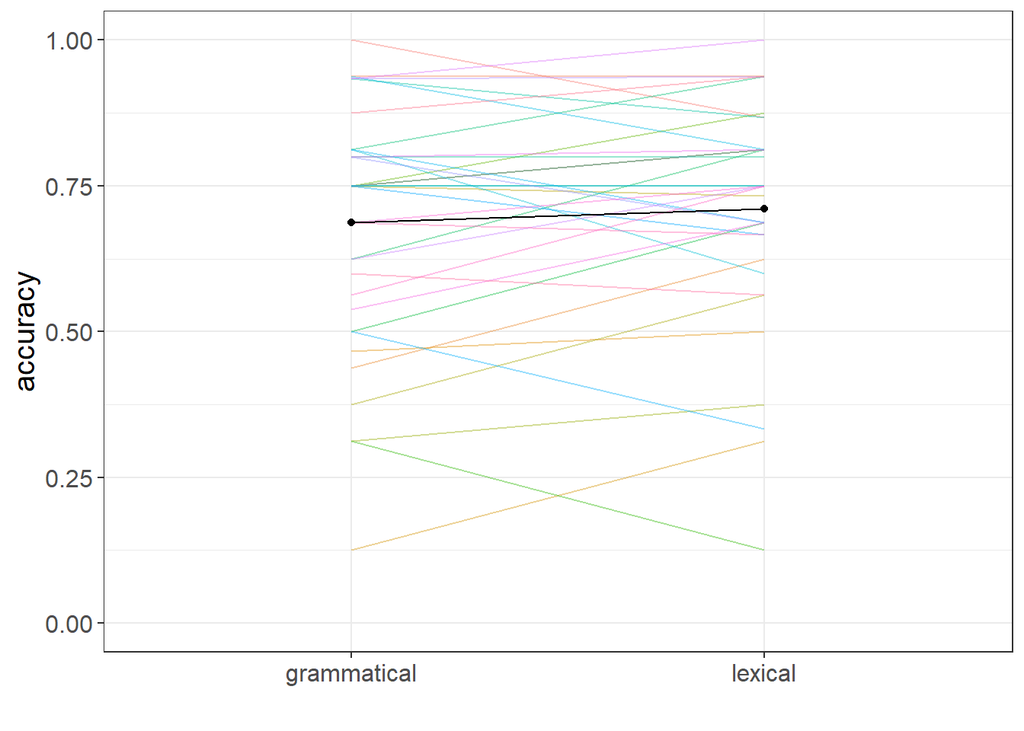

```r
ggsave("figures/accuracy_barplot.png", plot = accuracy_barplot, width = 6, height = 4)

# line plot where each line is a participant
# -------------------------------------------

line_plot_accuracy <- df_participant_mean %>%
  ggplot(aes(affix_type, mean_accuracy)) +
  geom_line(data = df_participant_mean, aes(affix_type, mean_accuracy, group = participant, color = participant), alpha = 0.4) +
  # geom_errorbar(aes(ymin = correct_ratio - 0.01, ymax = correct_ratio + 0.01), width = 0.1) +
  stat_summary(fun = mean, geom = 'point', aes(group = 1)) +
  stat_summary(fun = mean, geom = 'line', aes(group = 1), linewidth = 0.5) +
  theme_bw() +
  theme(legend.position = 'none', axis.text = element_text(size = 12), axis.title = element_text(size = 15)) +
  labs(x = '', y = 'accuracy') +
  ylim(0, 1)

line_plot_accuracy
```

```r
ggsave("figures/line_plot_accuracy.png", plot = line_plot_accuracy, width = 6, height = 4)
```

## Model to assess the effect of lexical/grammatical condition on accuracy

```r
model1_affix_type <- glmer(correct_incorrect ~ affix_type + (1|participant),
                          family = 'binomial',
                          df_clean_affix)

summary(model1_affix_type)
```

```
## Generalized linear mixed model fit by maximum likelihood (Laplace
##   Approximation) [glmerMod]
##  Family: binomial  ( logit )
## Formula: correct_incorrect ~ affix_type + (1 | participant)
##    Data: df_clean_affix
##
##      AIC      BIC   logLik deviance df.resid
##   1291.0   1306.1   -642.5   1285.0     1129
##
## Scaled residuals:
##     Min      1Q  Median      3Q     Max
## -3.0931 -0.7859  0.4399  0.6132  1.6135
##
## Random effects:
##  Groups      Name        Variance Std.Dev.
##  participant (Intercept) 0.8038   0.8965
## Number of obs: 1132, groups:  participant, 36
##
## Fixed effects:
##                   Estimate Std. Error z value Pr(>|z|)
## (Intercept)         0.9116     0.1799   5.067 4.04e-07 ***
## affix_typelexical   0.1344     0.1390   0.967    0.334
## ---
## Signif. codes:  0 '***' 0.001 '**' 0.01 '*' 0.05 '.' 0.1 ' ' 1
##
## Correlation of Fixed Effects:
##             (Intr)
## affx_typlxc -0.376
```

A second model which includes affix frequency and length as predictors:

```r
# read csv containing affix frequencies ad calculate log10 frequency
frequencies <- read.csv("research materials/suffix_frequencies.csv", sep = ";")
frequencies <- frequencies %>%
  mutate(log10freq = log10(frequency))

# merge frequency info with affix data frame
df_clean_affix_merged <- merge(df_clean_affix, frequencies, by.x = "target_affix", by.y = "suffix")

# add length column
df_clean_affix_merged <- df_clean_affix_merged %>%
  mutate(affix_length = nchar(target_affix))

# model which includes frequency and lengt as predictors
model2_affix_type <- glmer(correct_incorrect ~ affix_type +
                             log10freq + affix_length + (1|participant),
                          family = 'binomial',
                          df_clean_affix_merged)

summary(model2_affix_type)
```

```
## Generalized linear mixed model fit by maximum likelihood (Laplace
##   Approximation) [glmerMod]
##  Family: binomial  ( logit )
## Formula: correct_incorrect ~ affix_type + log10freq + affix_length + (1 |
##     participant)
##    Data: df_clean_affix_merged
##
##      AIC      BIC   logLik deviance df.resid
##    868.7    892.0   -429.4    858.7      773
##
## Scaled residuals:
##     Min      1Q  Median      3Q     Max
## -3.2762 -0.7594  0.4319  0.5875  1.5960
##
## Random effects:
##  Groups      Name        Variance Std.Dev.
##  participant (Intercept) 0.9434   0.9713
## Number of obs: 778, groups:  participant, 36
##
## Fixed effects:
##                   Estimate Std. Error z value Pr(>|z|)
## (Intercept)        0.88063    0.76887   1.145    0.252
## affix_typelexical  0.17460    0.18422   0.948    0.343
## log10freq         -0.08662    0.14569  -0.595    0.552
## affix_length       0.06756    0.05794   1.166    0.244
##
## Correlation of Fixed Effects:
##             (Intr) affx_t lg10fr
## affx_typlxc  0.038
## log10freq   -0.829 -0.285
## affix_lngth -0.765  0.091  0.369
```

## Looking at accuracy rates for the specific target suffixes

```r
# bar plot for specific suffixes
# ---------------------------------

# grouping by participant, target affix and affix type and calculating accuracy
df_affixes <- df_clean_affix %>%
  group_by(participant, target_affix, affix_type) %>%
  summarise(
    accuracy = mean(correct_incorrect)
  )
```

```
## `summarise()` has regrouped the output.
## ℹ Summaries were computed grouped by participant, target_affix, and affix_type.
## ℹ Output is grouped by participant and target_affix.
## ℹ Use `summarise(.groups = "drop_last")` to silence this message.
## ℹ Use `summarise(.by = c(participant, target_affix, affix_type))` for
##   per-operation grouping (`?dplyr::dplyr_by`) instead.
```

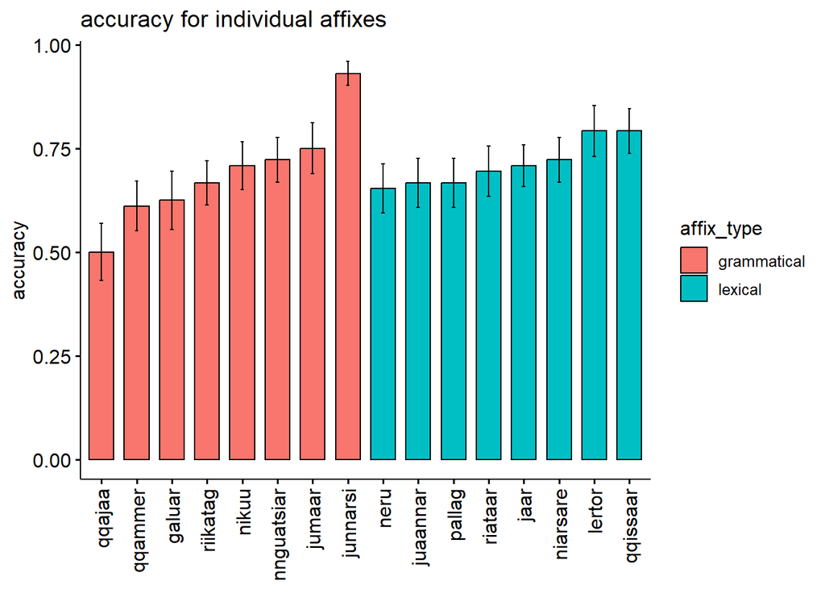

```r
# plotting
plot_suffixes <- ggbarplot(df_affixes, x = "target_affix", y = "accuracy",
                          add = c("mean_se"),
                          fill = "affix_type",
                          x.text.angle = 90,  # Rotate x-axis labels vertically
                          xlab = FALSE,
                          legend = "right",
                          title = "accuracy for individual affixes",
                          sort.val = "asc"
)

plot_suffixes
```

```r
ggsave("figures/bar_plot_suffixes.png", plot = plot_suffixes, width = 6, height = 4)
```

# Post-hoc analyses

## Accuracy by reading speed

We saw that accuracy varied a lot between participants. But how does this relate to individual reading speed? Here we plot each participant’s mean accuracy on the target trials by that participant’s mean reading time for the first sentence in a trial.

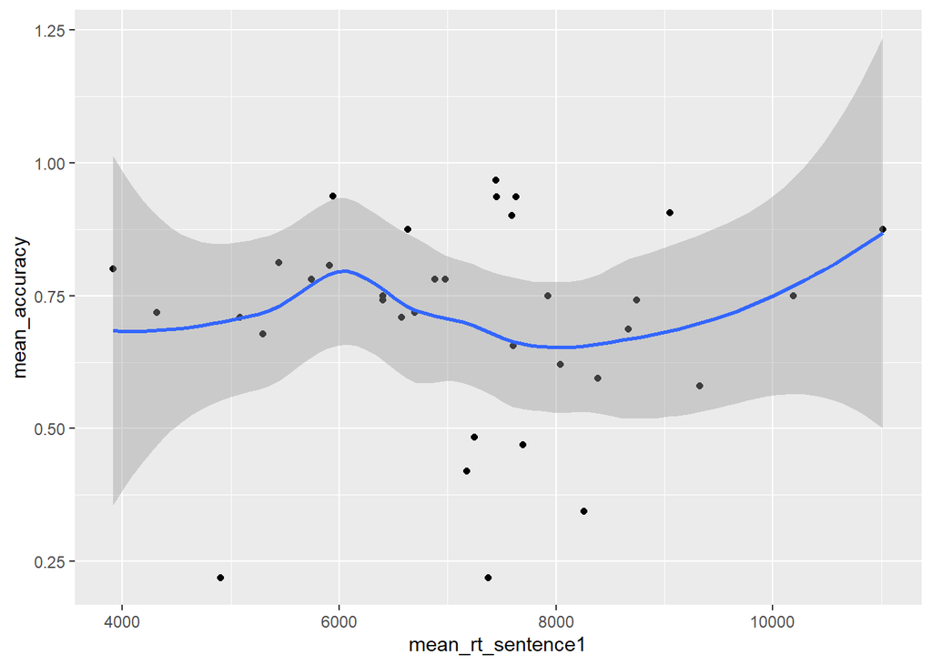

```r
# get mean reading times for sentence 1
df_rt_sentence1 <- rt_long %>%
  filter(stage == "mean_rt_sentence1")
names(df_rt_sentence1)[names(df_rt_sentence1) == "rt"] <- "mean_rt_sentence1"

# merge with df_clean_affix
df_clean_affix2 <- merge(df_clean_affix, df_rt_sentence1, by = "participant")

# plot mean accuracy
mean_accuracy_and_rt <- df_clean_affix2 %>%
  group_by(participant) %>%
  summarise(mean_rt_sentence1 = first(mean_rt_sentence1),
            mean_accuracy = mean(correct_incorrect))

# exclude outlier
# (this person was not excluded from the main analyses because the amount of time
# they spent on the task was just below the exclusion threshold
# - but they were far slower than the others so we exclude them here for the sake
# of the plot)
mean_accuracy_and_rt <- mean_accuracy_and_rt %>%
  filter(participant != "5kqwq452")

mean_accuracy_by_rt_plot <- ggplot(aes(x = mean_rt_sentence1, y = mean_accuracy),
                                   data = mean_accuracy_and_rt) +
  geom_point() +
  geom_smooth()

mean_accuracy_by_rt_plot
```

There is no clear connection at the participant level between mean reading time and the accuracy with which one detects affix omissions.

But what if we standardize the reading time measure within each participant? Then we can see if reading faster or slower than one usually does impacts change detection accuracy for affixes.

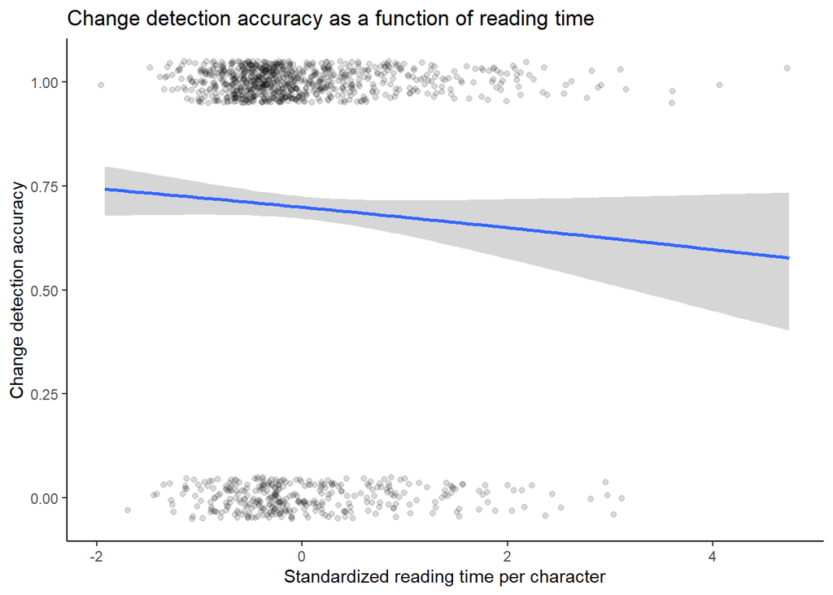

```r
# first calculate RT pr character for sentence 1 in each trial
# (because the sentences are not all equal in length)

sentence_df <- df_clean %>%
  group_by(sentence_id_specific) %>%
  summarise(sentence1 = first(original_sentence))

rt_per_character <- reading_time_first_sentence %>%
  filter(!(sentence_id_specific %in% c("p1", "p2", "p3", "p4", NA)))

rt_per_character$sentence1 <- sentence_df$sentence1[
  match(rt_per_character$sentence_id_specific, sentence_df$sentence_id_specific)
]

rt_per_character <- rt_per_character %>%
  mutate(rt_per_char = reading_time_sentence1 / nchar(sentence1))

# then center and standardize this measure within each participant

rt_per_character <- rt_per_character %>%
  group_by(participant) %>%
  mutate(
    rt_per_char_centered = rt_per_char - mean(rt_per_char, na.rm = TRUE),
    rt_per_char_z = as.numeric(scale(rt_per_char))
  ) %>%
  ungroup()

# merge with df_clean_affix
df_accuracy_and_rt <- df_clean_affix %>%
  left_join(rt_per_character, by = c("sentence_id_specific", "participant"))

# now plot accuracy by standardized rt

accuracy_by_rt_plot <- ggplot(
  df_accuracy_and_rt,
  aes(x = rt_per_char_z, y = correct_incorrect)
) +
  geom_jitter(
    height = 0.05,
    width = 0.05,
    alpha = 0.15
  ) +
  geom_smooth(
    method = "glm",
    method.args = list(family = "binomial"),
    se = TRUE
  ) +
  labs(
    x = "Standardized reading time per character",
    y = "Change detection accuracy",
    title = "Change detection accuracy as a function of reading time"
  ) +
  theme_classic()

accuracy_by_rt_plot
```

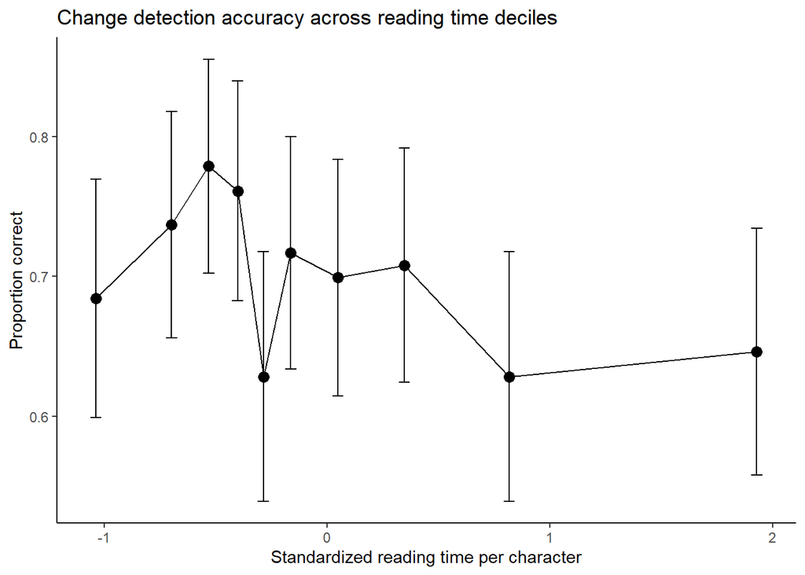

```r
# different plot: binned

accuracy_binned <- df_accuracy_and_rt %>%
  mutate(rt_bin = ntile(rt_per_char_z, 10)) %>%
  group_by(rt_bin) %>%
  summarise(
    mean_rt = mean(rt_per_char_z, na.rm = TRUE),
    accuracy = mean(correct_incorrect, na.rm = TRUE),
    n = n(),
    se = sqrt(accuracy * (1 - accuracy) / n),
    .groups = "drop"
  )

ggplot(accuracy_binned, aes(x = mean_rt, y = accuracy)) +
  geom_point(size = 3) +
  geom_line() +
  geom_errorbar(
    aes(ymin = accuracy - 1.96 * se,
        ymax = accuracy + 1.96 * se),
    width = 0.05
  ) +
  labs(
    x = "Standardized reading time per character",
    y = "Proportion correct",
    title = "Change detection accuracy across reading time deciles"
  ) +
  theme_classic()
```

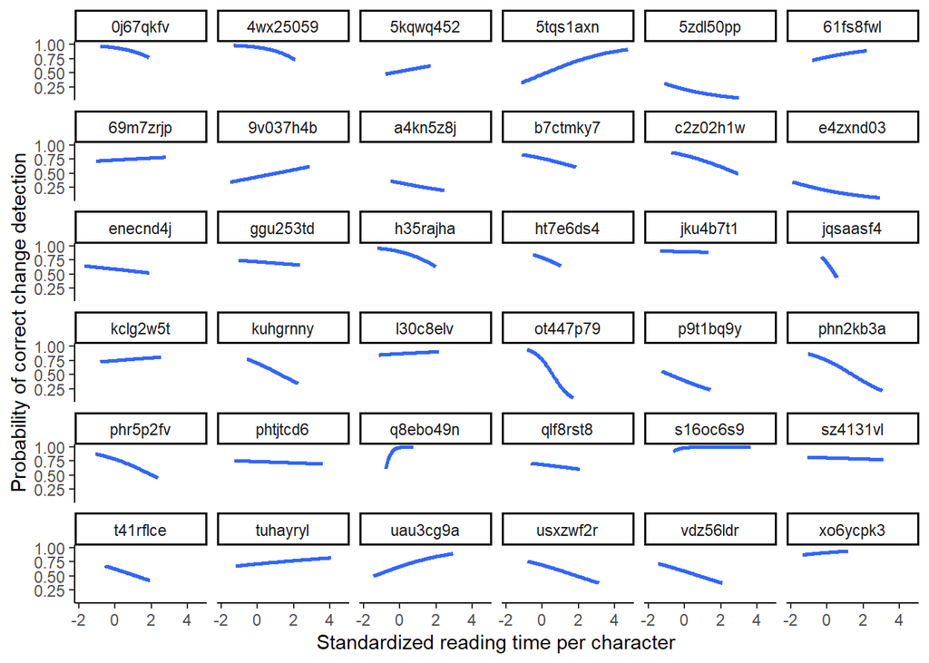

```r
# plotting individual participant trends

ggplot(
  df_accuracy_and_rt,
  aes(x = rt_per_char_z, y = correct_incorrect)
) +
  geom_smooth(
    method = "glm",
    method.args = list(family = "binomial"),
    se = FALSE
  ) +
  facet_wrap(~ participant) +
  labs(
    x = "Standardized reading time per character",
    y = "Probability of correct change detection"
  ) +
  theme_classic()
```

Overall, there is no clear relationship between reading time and change detection accuracy. It is not the case in general that if participants read a sentence more slowly then they are better at detection when an affix is deleted from that sentence.

## Lexical advantage by reading speed

But what about the lexical/grammatical distinction? Could it be the case that a lexical advantage emerges only when people’s reading speed is sufficiently close to normal? (slow reading could mean that every morpheme is processed quite deeply, while fast reading could mean that processing is too shallow for lexical-grammatical differences to emerge). This question can once again be asked both at the level of participant means AND at the within-participant level.

First, let’s look at the participant means.

```r
df_lexical_advantage <- df_clean_affix2 %>%
  group_by(participant, mean_rt_sentence1, affix_type) %>%
  summarise(mean_accuracy = mean(correct_incorrect))
```

```
## `summarise()` has regrouped the output.
## ℹ Summaries were computed grouped by participant, mean_rt_sentence1, and
##   affix_type.
## ℹ Output is grouped by participant and mean_rt_sentence1.
## ℹ Use `summarise(.groups = "drop_last")` to silence this message.
## ℹ Use `summarise(.by = c(participant, mean_rt_sentence1, affix_type))` for
##   per-operation grouping (`?dplyr::dplyr_by`) instead.
```

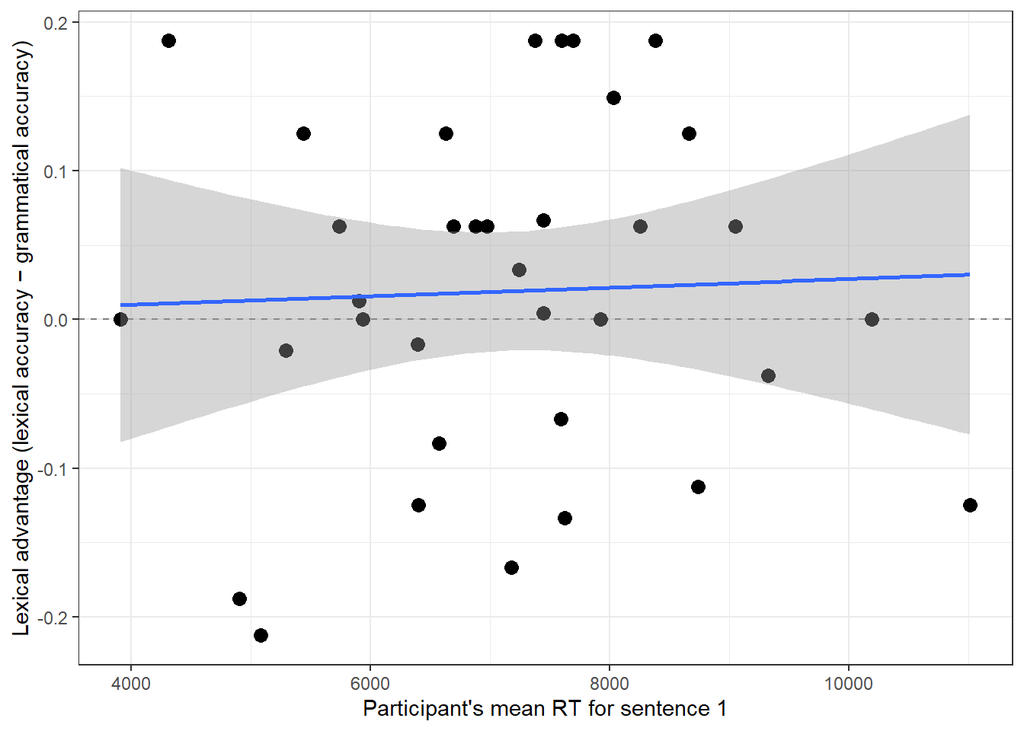

```r
df_lexical_advantage_wider <- df_lexical_advantage %>%
  select(participant, affix_type, mean_accuracy, mean_rt_sentence1) %>%
  pivot_wider(
    names_from = affix_type,
    values_from = mean_accuracy
  ) %>%
  mutate(
    lexical_advantage = lexical - grammatical
  )

# exclude outlier
df_lexical_advantage_wider <- df_lexical_advantage_wider %>%
  filter(participant != "5kqwq452")

lexical_advantage_plot <- ggplot(df_lexical_advantage_wider,
                                 aes(x = mean_rt_sentence1, y = lexical_advantage)) +
  geom_hline(yintercept = 0, linetype = "dashed", colour = "grey50") +
  geom_point(size = 3) +
  geom_smooth(
    method = "lm",
    se = TRUE
  ) +
  labs(
    x = "Participant's mean RT for sentence 1",
    y = "Lexical advantage (lexical accuracy − grammatical accuracy)"
  ) +
  theme_bw()

lexical_advantage_plot
```

There is absolutely no pattern connecting overall reading speed to lexical advantage.

But what if we once again look at the standardizes reading times within each participant? Then we can see if reading faster or slower than one usually does impacts lexical advantage.

```r
df_lex_advan_within_subj <- df_accuracy_and_rt %>%
  group_by(participant, sentence_id, affix_type, rt_per_char_z) %>%
  summarise(accuracy = first(correct_incorrect))
```

```
## `summarise()` has regrouped the output.
## ℹ Summaries were computed grouped by participant, sentence_id, affix_type, and
##   rt_per_char_z.
## ℹ Output is grouped by participant, sentence_id, and affix_type.
## ℹ Use `summarise(.groups = "drop_last")` to silence this message.
## ℹ Use `summarise(.by = c(participant, sentence_id, affix_type, rt_per_char_z))`
##   for per-operation grouping (`?dplyr::dplyr_by`) instead.
```

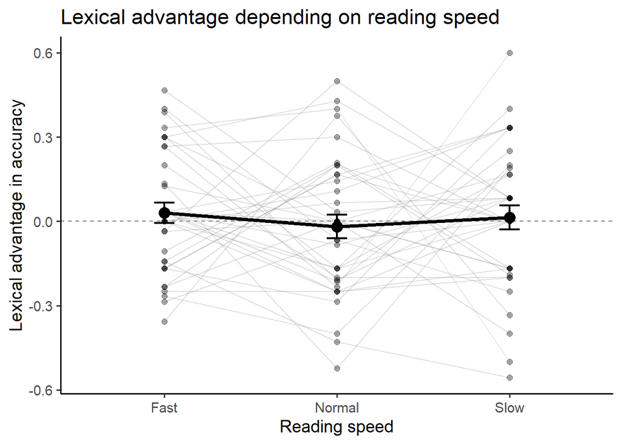

```r
# group by participant and divide trials into three bins: slow, normal, fast
df_binned <- df_lex_advan_within_subj %>%
  group_by(participant) %>%
  mutate(
    speed_bin = ntile(rt_per_char_z, 3),
    speed_bin = factor(
      speed_bin,
      levels = 1:3,
      labels = c("Fast", "Normal", "Slow")
    )
  ) %>%
  ungroup()

# calculate accuracy per condition and bin
df_accuracy <- df_binned %>%
  group_by(participant, speed_bin, affix_type) %>%
  summarise(
    accuracy = mean(accuracy, na.rm = TRUE),
    .groups = "drop"
  )

# calculate lexical advantage
df_advantage <- df_accuracy %>%
  tidyr::pivot_wider(
    names_from = affix_type,
    values_from = accuracy
  ) %>%
  mutate(
    lexical_advantage = lexical - grammatical
  )

# plot
ggplot(
  df_advantage,
  aes(x = speed_bin, y = lexical_advantage,
      group = participant)
) +
  geom_hline(
    yintercept = 0,
    linetype = "dashed",
    color = "grey50"
  ) +
  geom_line(
    alpha = 0.25,
    color = "grey50"
  ) +
  geom_point(
    alpha = 0.35,
    size = 2
  ) +
  stat_summary(
    aes(group = 1),
    fun = mean,
    geom = "line",
    linewidth = 1.3,
    color = "black"
  ) +
  stat_summary(
    aes(group = 1),
    fun = mean,
    geom = "point",
    size = 4,
    color = "black"
  ) +
  stat_summary(
    aes(group = 1),
    fun.data = mean_se,
    geom = "errorbar",
    width = 0.12,
    linewidth = 0.8
  ) +
  labs(
    x = "Reading speed",
    y = "Lexical advantage in accuracy",
    title = "Lexical advantage depending on reading speed"
  ) +
  theme_classic(base_size = 14)
```

# Looking at sentence ratings

In part 2 of the experiment, we asked all participants to rate all the target sentences on a scale from “sounds like a beginner Kalaallisut speaker” to “sounds like a native Kalaallisut speaker”. Here we take a look at the results of those ratings.

```r
# removing rows we are not interested in
df_rating <- subset(data_frame, slider_start != "")

# mean rating by sentence id
rating_by_id <- df_rating %>%
  group_by(sentence_id) %>%
  summarise(mean_rating = mean(rating_response))
rating_by_id
```

```
## # A tibble: 20 × 2
##    sentence_id mean_rating
##    <chr>             <dbl>
##  1 1                  57.6
##  2 10                 68.8
##  3 11                 62.4
##  4 12                 64.4
##  5 13                 69.6
##  6 14                 67.6
##  7 15                 71.4
##  8 16                 75.2
##  9 2                  64.2
## 10 3                  62.1
## 11 4                  65.0
## 12 5                  66.0
## 13 6                  67.8
## 14 7                  63.2
## 15 8                  70.5
## 16 9                  65.4
## 17 ungram_1           12.1
## 18 ungram_2           13
## 19 ungram_3           25.7
## 20 ungram_4           45.6
```

```r
# mean rating by condition
rating_by_condition <- df_rating %>%
  group_by(condition) %>%
  summarise(mean_rating = mean(rating_response))
rating_by_condition
```

```
## # A tibble: 5 × 2
##   condition         mean_rating
##   <chr>                   <dbl>
## 1 grammatical_affix        71.4
## 2 lexical_affix            72.0
## 3 no_affix                 77.7
## 4 no_subject               44.1
## 5 ungrammatical            24.2
```